# R2BEAT two-stage sampling design workflow starting from a previous survey

2023-05-17

This vignette describes a generalized procedure making use of the methods implemented in the R package developed in the Italian National Institute, namely R2BEAT (“Multistage Sampling Allocation and PSU selection”).

This package allows to determine the optimal allocation of both Primary Stage Units (PSUs) and Secondary Stage Units (SSU), and also to perform a selection of the PSUs such that the final sample of SSU is of the self-weighting type, i.e. the total inclusion probabilities (as resulting from the product between the inclusion probabilities of the PSUs and those of the SSUs) are near equal for all SSUs, or at least those of minimum variability.

This general flow assumes that at least a previous round of the survey, whose sampling design has to be optimized, is available, and is characterized by the following steps:

# 1 Use of ReGenesees

Perform externally the definition of the sample design, and possibly of the calibration step, using the R package ReGenesees, and make the design object and the calibrated object available.

The workspace to be loaded (R2BEAT_ReGenesees.RData) is available at the link:

https://github.com/barcaroli/R2BEAT/tree/master/data

```r
load("R2BEAT_ReGenesees.RData")   # ReGenesees design object
```

This is the ‘design’ object:

```r
des
```

```
## Stratified 2 - Stage Cluster Sampling Design (with replacement)
## - [49] strata (collapsed)
## - [789, 2236] clusters
##
## Call:
## e.svydesign(sample_2st, ids = ~municipality + id_hh, strata = ~stratum_sub,
##     weights = ~d, self.rep.str = ~SR, check.data = TRUE)
```

and this is the calibrated object:

```r
cal
```

```
## Calibrated, Stratified 2 - Stage Cluster Sampling Design (with replacement)
## - [49] strata (collapsed)
## - [789, 2236] clusters
##
## Call:
## e.calibrate(design = des, df.population = pop, calmodel = ~clage:sex -
##     1, partition = ~region, calfun = "logit", bounds = c(0.7,
##     1.7), aggregate.stage = 2, force = FALSE)
```

It is advisable to check the presence of lonely strata:

```r
# Control the presence of strata with less than two units
ls <- find.lon.strata(des)
```

```
## # No lonely PSUs found!
```

In case, provide to collapse and re-do the calibration.

In this example, in the ReGenesees objects there are the following variables:

```r
str(des$variables)
```

```
## 'data.frame':    2244 obs. of  17 variables:
##  $ region               : Factor w/ 3 levels "north","center",..: 1 1 1 1 1 1 1 1 1 1 ...
##  $ municipality         : num  8 8 8 8 8 8 8 8 8 8 ...
##  $ stratum              : Factor w/ 24 levels "1000","2000",..: 9 9 9 9 9 9 9 9 9 9 ...
##  $ stratum_sub          : Factor w/ 81 levels "100001","100002",..: 81 81 81 81 81 81 81 81 81 81 ...
##  $ SR                   : Factor w/ 2 levels "0","1": 2 2 2 2 2 2 2 2 2 2 ...
##  $ id_hh                : Factor w/ 2236 levels "H100070","H100410",..: 69 43 64 49 367 27 372 373 374 368 ...
##  $ sex                  : Factor w/ 2 levels "1","2": 1 1 2 2 1 2 1 2 1 1 ...
##  $ clage                : Factor w/ 5 levels "cl0_17","cl18_34",..: 3 1 2 1 5 2 2 2 3 1 ...
##  $ income_hh            : num  43741 23284 23450 22171 19904 ...
##  $ work                 : num  1 1 1 2 0 1 1 1 1 2 ...
##  $ unemployed           : num  0 0 0 0 1 0 0 0 0 0 ...
##  $ d                    : num  1238 1238 1238 1238 1238 ...
##  $ progr_str            : num  1 1 1 1 1 1 1 1 1 1 ...
##  $ var.PSU              : chr  "8.H12425" "8.H10738" "8.H12157" "8.H11208" ...
##  $ stratum_sub.collapsed: Factor w/ 49 levels "0.center.clps.1",..: 49 49 49 49 49 49 49 49 49 49 ...
##  $ active               : Factor w/ 2 levels "0","1": 2 2 2 1 1 2 2 2 2 1 ...
##  $ inactive             : Factor w/ 2 levels "0","1": 1 1 1 2 1 1 1 1 1 2 ...
```

where there are three potential target variables:

1. income_hh (numeric);
2. work (factor with values 0, 1, 2);
3. unemployed (factor with values 0, 1).

```r
summary(des$variables$income_hh)
```

```
##    Min. 1st Qu.  Median    Mean 3rd Qu.    Max.
##       0   11463   18516   21661   26763  532331
```

```r
table(des$variables$work)
```

```
##
##    0    1    2
##  306 1487  451
```

```r
table(des$variables$unemployed)
```

```
##
##    0    1
## 1938  306
```

Great attention must be paid to the nature of the target variables, especially of the ‘factor’ type. In fact, the procedure here illustrated is suitable only when categorical variables are binary with values 0 and 1, supposing we are willing to estimate proportions of ‘1’ in the population. If factor variables are of other nature, then an error message is printed.

# 2 Build ‘strata’, ‘deff’, ‘effst’ and ‘rho’ dataframes

Using ReGenesees objects as input, produce the following dataframes (function ‘input_to_beat.2st_1’):

1. the ‘stratif’ dataframe containing:
- STRATUM: identifier of the single stratum
- N: total population in terms of final sampling units
- Mi,Si: mean and standard deviation of target variables (i=1,2,..,P)
- DOMk: domain(s) to which the stratum belongs
2. the ‘deff’ (design effect) dataframe, containing the following information:
- STRATUM: the stratum identifier
- DEFFi: the design effect for each target variable i (i=1,2,…,P)
3. the ‘effst’ (estimator effect) dataframe, containing the following information:
- STRATUM: the stratum identifier
- EFFSTi: the estimator effect for each target variable i (i=1,2,…,P)
4. the ‘rho’ (intraclass coefficient of correlation) dataframe, containing the following information:
- STRATUM: the stratum identifier
- RHO_ARi: the intraclass coefficient of correlation in self-representative PSUs for each target variable i (i=1,2,…,P)
- RHO_NARi: the intraclass coefficient of correlation in non self-representative PSUs for each target variable i (i=1,2,…,P)

Actually, the ‘deff’ dataframe is not used in the following steps, it just remains for documentation purposes.

Here is the way we can produce the above items:

```r
load("pop.RData")
samp_frame <- pop
RGdes <- des
RGcal <- cal
strata_var <- c("stratum")
target_vars <- c("income_hh",
                 "active",
                 "inactive",
                 "unemployed")
weight_var <- "weight"
deff_var <- "stratum"
id_PSU <- c("municipality")
id_SSU <- c("id_hh")
domain_var <- c("region")
delta <- 1
minimum <- 25

inp <- prepareInputToAllocation2(
        samp_frame,  # sampling frame
        RGdes,       # ReGenesees design object
        RGcal,       # ReGenesees calibrated object
        id_PSU,      # identification variable of PSUs
        id_SSU,      # identification variable of SSUs
        strata_var,  # strata variables
        target_vars, # target variables
        deff_var,    # deff variables
        domain_var,  # domain variables
        delta,       # Average number of SSUs for each selection unit
        minimum      # Minimum number of SSUs to be selected in each PSU
      )
```

and these are the results:

```r
head(inp$strata)
```

| stratum | N | STRATUM | M1 | M2 | M3 | M4 | S1 | S2 | S3 | S4 | COST | CENS | DOM1 | DOM2 |
| --- | --- | --- | --- | --- | --- | --- | --- | --- | --- | --- | --- | --- | --- | --- |
| 1000 | 197451 | 1000 | 22266.58 | 0.6404431 | 0.2323140 | 0.1272429 | 14554.88 | 0.4798705 | 0.4223082 | 0.3332449 | 1 | 0 | 1 | center |
| 10000 | 106106 | 10000 | 27985.40 | 0.7679285 | 0.2114187 | 0.0206528 | 24367.97 | 0.4221544 | 0.4083146 | 0.1422189 | 1 | 0 | 1 | north |
| 11000 | 202700 | 11000 | 29173.85 | 0.8029080 | 0.1730880 | 0.0240040 | 39232.92 | 0.3978024 | 0.3783234 | 0.1530613 | 1 | 0 | 1 | north |
| 12000 | 57420 | 12000 | 26937.42 | 0.7764955 | 0.2075926 | 0.0159119 | 15743.78 | 0.4165936 | 0.4055834 | 0.1251347 | 1 | 0 | 1 | north |
| 13000 | 103089 | 13000 | 26357.25 | 0.7185271 | 0.2814729 | 0.0000000 | 14592.50 | 0.4497176 | 0.4497176 | 0.0000000 | 1 | 0 | 1 | north |
| 14000 | 84653 | 14000 | 20538.42 | 0.7518236 | 0.2131042 | 0.0350721 | 14285.81 | 0.4319547 | 0.4095007 | 0.1839621 | 1 | 0 | 1 | north |

```r
head(inp$deff)
```

| stratum | STRATUM | DEFF1 | DEFF2 | DEFF3 | DEFF4 | b_nar |
| --- | --- | --- | --- | --- | --- | --- |
| 1000 | 1000 | 0.960198 | 0.999984 | 1.015715 | 0.962537 | 56.50000 |
| 10000 | 10000 | 0.864671 | 1.703511 | 1.417543 | 0.827580 | 26.75000 |
| 11000 | 11000 | 1.820304 | 1.267734 | 1.352970 | 1.345746 | 23.77778 |
| 12000 | 12000 | 1.103866 | 0.510554 | 0.491751 | 0.711980 | 21.00000 |
| 13000 | 13000 | 1.000924 | 1.000924 | 1.000924 | 1.000000 | 95.00000 |
| 14000 | 14000 | 0.639871 | 0.865378 | 0.854025 | 0.684041 | 33.66667 |

```r
head(inp$effst)
```

| stratum | STRATUM | EFFST1 | EFFST2 | EFFST3 | EFFST4 |
| --- | --- | --- | --- | --- | --- |
| 1000 | 1000 | 0.9689481 | 1 | 1 | 0.9420957 |
| 10000 | 10000 | 0.9500006 | 1 | 1 | 1.1915489 |
| 11000 | 11000 | 0.9544521 | 1 | 1 | 1.0546195 |
| 12000 | 12000 | 1.0429454 | 1 | 1 | 0.9732492 |
| 13000 | 13000 | 1.0019592 | 1 | 1 | 1.0000000 |
| 14000 | 14000 | 0.9829169 | 1 | 1 | 1.0974518 |

```r
head(inp$rho)
```

| STRATUM | RHO_AR1 | RHO_NAR1 | RHO_AR2 | RHO_NAR2 | RHO_AR3 | RHO_NAR3 | RHO_AR4 | RHO_NAR4 |
| --- | --- | --- | --- | --- | --- | --- | --- | --- |
| 1000 | 1 | -0.0007172 | 1 | -0.0000003 | 1 | 0.0002832 | 1 | -0.0006750 |
| 10000 | 1 | -0.0052555 | 1 | 0.0273208 | 1 | 0.0162153 | 1 | -0.0066959 |
| 11000 | 1 | 0.0360133 | 1 | 0.0117542 | 1 | 0.0154962 | 1 | 0.0151791 |
| 12000 | 1 | 0.0051933 | 1 | -0.0244723 | 1 | -0.0254124 | 1 | -0.0144010 |
| 13000 | 1 | 0.0000098 | 1 | 0.0000098 | 1 | 0.0000098 | 1 | 0.0000000 |
| 14000 | 1 | -0.0110244 | 1 | -0.0041211 | 1 | -0.0044686 | 1 | -0.0096722 |

```r
head(inp$psu_file)
```

| PSU_ID | STRATUM | PSU_MOS |
| --- | --- | --- |
| 309 | 1000 | 50845 |
| 330 | 1000 | 146162 |
| 292 | 2000 | 24794 |
| 293 | 2000 | 19609 |
| 300 | 2000 | 13897 |
| 304 | 2000 | 36195 |

```r
head(inp$des_file)
```

| STRATUM | STRAT_MOS | DELTA | MINIMUM |
| --- | --- | --- | --- |
| 1000 | 197007 | 1 | 25 |
| 2000 | 261456 | 1 | 25 |
| 3000 | 115813 | 1 | 25 |
| 4000 | 17241 | 1 | 25 |
| 5000 | 101067 | 1 | 25 |
| 6000 | 47218 | 1 | 25 |

# 3 Check the coherence of populations in strata and PSUs

It may happen that the population in strata (variable ‘N’ in ‘inp1$strata’ dataset) and the one derived by the PSU dataset (variable ‘STRAT_MOS’ in ‘inp2$des_file’ dataset) are not the same.

We can check it by applying the function ‘check_input’ in this way:

```r
newstrata <- check_input(strata=inp$strata,
                         des=inp$des_file,
                         strata_var_strata="STRATUM",
                         strata_var_des="STRATUM")
```

```
##
## --------------------------------------------------
##  Differences between population in strata and PSUs
## --------------------------------------------------
##    STRATUM N_in_strata N_in_PSUs relative_difference
## 1     1000      197451    197007              -0.002
## 12    2000      258193    261456               0.012
## 18    3000      116213    115813              -0.003
## 19    4000       17879     17241              -0.037
## 20    5000      102706    101067              -0.016
## 21    6000       47477     47218              -0.005
## 22    7000       30193     30370               0.006
## 23    8000       26580     26518              -0.002
## 24    9000       94610     92833              -0.019
## 2    10000      106106    106030              -0.001
```

[output cut: 17 more lines]

Together with the print of the differences between the two populations, the function produces a new version of the strata dataset, where the population has been changed to the one derived by the PSUs dataset.

It is preferable to use this new version:

```r
inp$strata <- newstrata
```

# 4 Optimal allocation of units in each stratum

Using the function ‘beat.2st’ in ‘R2BEAT’ package execute the optimization of PSU and SSU allocation in strata:

```r
cv <- as.data.frame(list(DOM=c("DOM1","DOM2"),
                         CV1=c(0.02,0.03),
                         CV2=c(0.03,0.05),
                         CV3=c(0.03,0.05),
                         CV4=c(0.05,0.08)))
cv
```

| DOM | CV1 | CV2 | CV3 | CV4 |
| --- | --- | --- | --- | --- |
| DOM1 | 0.02 | 0.03 | 0.03 | 0.05 |
| DOM2 | 0.03 | 0.05 | 0.05 | 0.08 |

```r
set.seed(1234)
minPSUstrat <- 2
inp$des_file$MINIMUM <- 25
alloc <- beat.2st(stratif = inp$strata,
                  errors = cv,
                  des_file = inp$des_file,
                  psu_file = inp$psu_file,
                  rho = inp$rho,
                  deft_start = NULL,
                  effst = inp$effst,
                  minnumstrat = 2,
                  minPSUstrat)
```

```
##    iterations PSU_SR PSU NSR PSU Total    SSU
## 1           0      0       0         0   7721
## 2           1    111      72       183 109498
## 3           2    155     114       269   7925
## 4           3    116     132       248   8660
## 5           4    146     122       268   8343
## 6           5    128     130       258   8580
## 7           6    143     124       267   8391
## 8           7    131     128       259   8550
## 9           8    143     124       267   8392
## 10          9    131     128       259   8550
## 11         10    143     124       267   8392
## 12         11    131     128       259   8550
## 13         12    143     124       267   8392
## 14         13    131     128       259   8550
## 15         14    143     124       267   8392
## 16         15    131     128       259   8550
## 17         16    143     124       267   8392
## 18         17    131     128       259   8550
## 19         18    143     124       267   8392
## 20         19    131     128       259   8550
## 21         20    143     124       267   8392
```

This is the sensitivity of the solution:

```r
alloc$sensitivity
```

|  | Type | Dom | V1 | V2 | V3 | V4 |
| --- | --- | --- | --- | --- | --- | --- |
| 2 | DOM1 | 1 | 1 | 0 | 1 | 1 |
| 6 | DOM2 | 1 | 1 | 0 | 8 | 1150 |
| 10 | DOM2 | 2 | 1 | 1 | 245 | 1 |
| 14 | DOM2 | 3 | 1 | 1 | 275 | 1 |

i.e., for each domain value and for each variable it is reported the gain in terms of reduction in the sample size if the corresponding precision constraint is reduced of 10%.

These are the expected values of the coefficients of variation:

```r
alloc$expected
```

|  | Type | Dom | V1 | V2 | V3 | V4 |
| --- | --- | --- | --- | --- | --- | --- |
| 2 | DOM1 | 1 | 0.0121 | 0.0104 | 0.0296 | 0.0307 |
| 6 | DOM2 | 1 | 0.0171 | 0.0132 | 0.0496 | 0.0800 |
| 10 | DOM2 | 2 | 0.0214 | 0.0209 | 0.0499 | 0.0675 |
| 14 | DOM2 | 3 | 0.0283 | 0.0242 | 0.0499 | 0.0339 |

# 5 Selection of PSUs

Using the function ‘select_PSU’ execute the selection of PSU in strata:

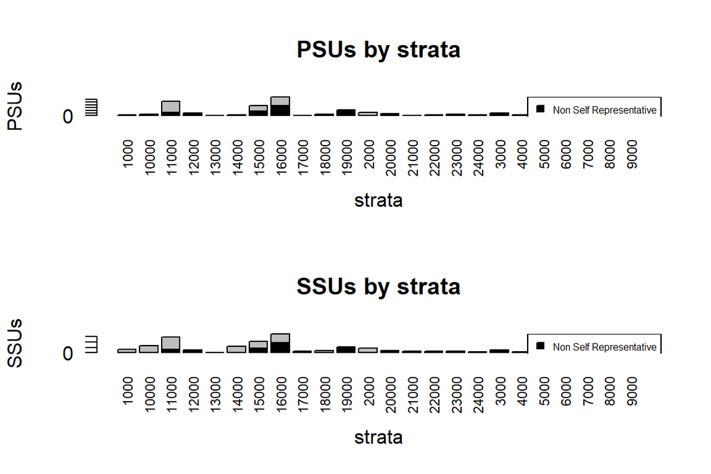

```r
set.seed(1234)
sample_1st <- select_PSU(alloc, type="ALLOC", pps=TRUE, plot=TRUE)
```

This is the overall sample design:

```r
sample_1st$PSU_stats
```

| STRATUM | PSU | PSU_SR | PSU_NSR | SSU | SSU_SR | SSU_NSR |
| --- | --- | --- | --- | --- | --- | --- |
| 1000 | 2 | 2 | 0 | 294 | 294 | 0 |
| 2000 | 13 | 13 | 0 | 405 | 405 | 0 |
| 3000 | 10 | 0 | 10 | 250 | 0 | 250 |
| 4000 | 2 | 0 | 2 | 50 | 0 | 50 |
| 5000 | 2 | 2 | 0 | 185 | 185 | 0 |
| 6000 | 3 | 3 | 0 | 82 | 82 | 0 |
| 7000 | 2 | 0 | 2 | 50 | 0 | 50 |
| 8000 | 2 | 0 | 2 | 50 | 0 | 50 |
| 9000 | 1 | 1 | 0 | 810 | 810 | 0 |
| 10000 | 6 | 6 | 0 | 644 | 644 | 0 |
| 11000 | 53 | 41 | 12 | 1432 | 1132 | 300 |
| 12000 | 10 | 0 | 10 | 250 | 0 | 250 |
| 13000 | 1 | 1 | 0 | 30 | 30 | 0 |
| 14000 | 4 | 4 | 0 | 607 | 607 | 0 |
| 15000 | 38 | 22 | 16 | 1021 | 621 | 400 |
| 16000 | 69 | 31 | 38 | 1725 | 775 | 950 |
| 17000 | 1 | 1 | 0 | 151 | 151 | 0 |
| 18000 | 6 | 6 | 0 | 199 | 199 | 0 |
| 19000 | 22 | 6 | 16 | 550 | 150 | 400 |
| 20000 | 8 | 0 | 8 | 200 | 0 | 200 |
| 21000 | 1 | 1 | 0 | 142 | 142 | 0 |
| 22000 | 3 | 3 | 0 | 109 | 109 | 0 |
| 23000 | 6 | 0 | 6 | 150 | 0 | 150 |
| 24000 | 2 | 0 | 2 | 50 | 0 | 50 |
| Total | 267 | 143 | 124 | 9436 | 6336 | 3100 |

# 6 Selection of SSUs

Finally, we are able to select the Secondary Sample Units (the individuals) from the already selected PSUs (the municipalities). We proceed to select the sample in this way:

```r
samp <- select_SSU(df=pop,
                   PSU_code="municipality",
                   SSU_code="id_ind",
                   PSU_sampled=sample_1st$sample_PSU)
```

```
##
## --------------------------------
## Total PSUs =  267
## Total SSUs =  9436
## --------------------------------
```

To check that the total amount of selected units with respect to the initial allocation:

```r
nrow(samp)
```

```
## [1] 9436
```

```r
sum(alloc$alloc$ALLOC[-nrow(alloc$alloc)])
```

```
## [1] 8392
```

The difference is due to the fact that the constraint on the minimum number of SSUs to be selected for PSU has been enforced, thus resulting in an increase of the SSUs with respect to the optimal allocation.

We check also that the sum of weights equalizes the population size:

```r
nrow(pop)
```

```
## [1] 2258507
```

```r
sum(samp$weight)
```

```
## [1] 2258507
```

This is the distribution of weights:

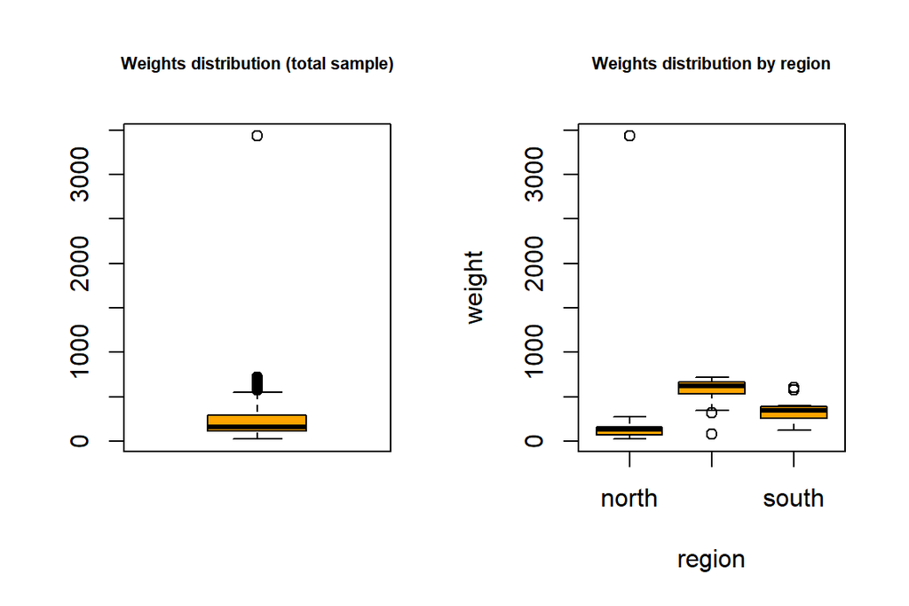

```r
par(mfrow=c(1, 2))
boxplot(samp$weight,col="orange")
title("Weights distribution (total sample)",cex.main=0.7)
boxplot(weight ~ region, data=samp,col="orange")
title("Weights distribution by region",cex.main=0.7)
```

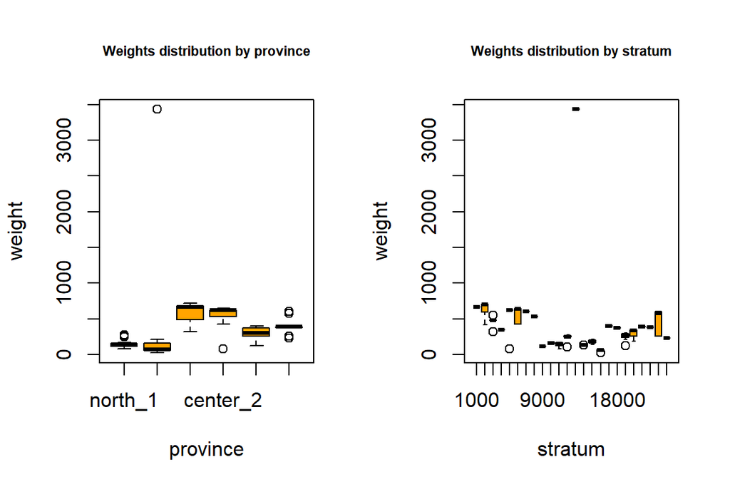

```r
boxplot(weight ~ province, data=samp,col="orange")
title("Weights distribution by province",cex.main=0.7)
boxplot(weight ~ stratum, data=samp,col="orange")
title("Weights distribution by stratum",cex.main=0.7)
```